# Procesos de Paz

Adrian Felipe Pinzon Hurtado

20/4/2021

# Explicación Dataset

Se tomarán los datos de los distintos procesos de paz a nivel mundial y luego discriminados para las américas, evaluando las siguientes variables:

**PP:** Código del nombre del proceso.

**Reg:** Región (continente) donde se desarrolla el conficto.

**Con:** País donde se desarrolla el conflico.

**Contp:** Tipo de conflicto (Gobierno, territorio, ambos, inter-grupo)

**Ver:** Indica cuál salida PA-X acordada fue publicada.

**LaRefRet:** Incluye restititución de Tierras o territorios. Es binaria con 1 si la incluye, y 0 si no incluye. Tiene que ver con mecanismo para restituir propiedades que fueron confiscadas, perdidas, destruidas o desplazadas a causa del conflicto.

**Lgt:** Tamaño del acuerdo en páginas. Tomado por un pdf e incluye títulos páginas en blanco, fotos y similares.

**N_characters:** Tamado del texto acordado por número de caracteres.

**BanPers:** Variable binaria que toma el valor de 1 si el acuerdo de paz esta lidiando con cuestiones de banca personal, acceso a cuentas y fondos, facilidad bancaria y facilidades comerciales bancarias.

**TjPower:** Variable binaria que toma el valor de 1 si el acuerdo de paz incluye anmistia, perdón y actores legislativos para crímenes no definidos (no necesariamente violencia pasada)Si las provisiones aparecen en el acuerdo, el valor es cero.

**TjVic:** Incluye cualquier provisión específica para asistencia de las víctimas del conflicto en este y otros términos.Toma los siguientes valores:

1 = por compromisos débiles y retóricos;

2 = compromisos sustantivos para el trato de las víctimas.

3 = provee fuertes compromisos para atender las vícitmas que incluye detalles del modos operandi.

**CowWar:** Correlaciones de guerra. ID Number.Muchos acuerdos de paz vienen de procesos en conflictos que no reunen los altos criterios de letalidad de las correlaciones de guerra por lo que los números de guerra no se proporcionan para muchos de los acuerdos. Más info de este item en https://correlatesofwar.org/

## 1.1. Lectura del Fichero

Se anexan salida en tabla del archivo procesado:

MUESTRA DE LA DATA

| Con | Contp | PP | Reg | AgtId | Ver | Lgt | N_characters | CowWar | BanPers | LaRefRet | TjPower | TjVic |
| --- | --- | --- | --- | --- | --- | --- | --- | --- | --- | --- | --- | --- |
| Afghanistan | Government/territory | 2 | Europe and Eurasia | 2232 | 3 | 2 | 5235 | 225 | 0 | 0 | 0 | 0 |
| Afghanistan | Government | 2 | Europe and Eurasia | 1739 | 2 | 4 | 10203 | 851 | 0 | 0 | 0 | 0 |
| Afghanistan | Government | 2 | Europe and Eurasia | 1923 | 2 | 4 | 11110 | 225 | 0 | 0 | 0 | 0 |
| Afghanistan | Government | 2 | Europe and Eurasia | 864 | 1 | 14 | 39746 | 225 | 1 | 0 | 0 | 1 |
| Afghanistan | Government | 2 | Europe and Eurasia | 848 | 1 | 7 | 24106 | 225 | 0 | 0 | 0 | 0 |
| Afghanistan | Government | 2 | Europe and Eurasia | 849 | 1 | 10 | 21299 | 225 | 0 | 0 | 0 | 0 |
| Afghanistan | Government | 2 | Europe and Eurasia | 709 | 1 | 9 | 33137 | 225 | 0 | 0 | 0 | 1 |
| Afghanistan | Government | 2 | Europe and Eurasia | 708 | 1 | 4 | 9289 | 225 | 0 | 0 | 0 | 0 |
| Afghanistan | Government | 2 | Europe and Eurasia | 707 | 1 | 7 | 27083 | 225 | 0 | 0 | 0 | 0 |
| Afghanistan | Government | 2 | Europe and Eurasia | 706 | 1 | 4 | 9555 | 225 | 0 | 0 | 0 | 0 |

EXPLORACIÓN DE VARIABLES POR TIPO

|  | Tipo Variable |
| --- | --- |
| Con | factor |
| Contp | factor |
| PP | integer |
| Reg | factor |
| AgtId | integer |
| Ver | integer |
| Lgt | integer |
| N_characters | integer |
| CowWar | integer |
| BanPers | integer |
| LaRefRet | integer |
| TjPower | integer |
| TjVic | integer |

## 1.2. Análisis Descriptivo Visual

### 1.2.1 Variables cualitativas

Representacion visual de variables representativas.

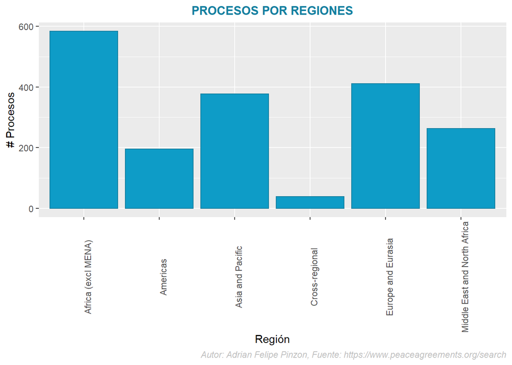

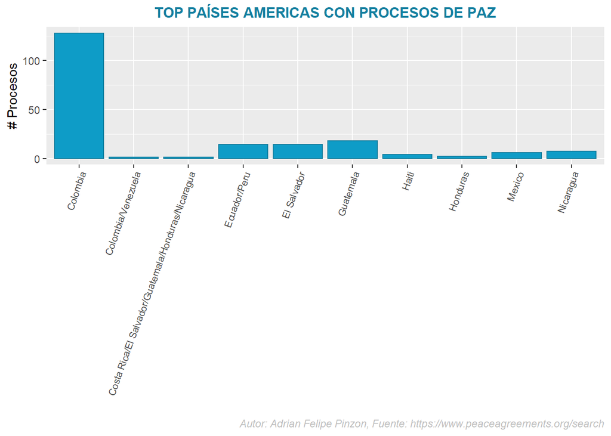

[figure not shown]

### 1.2.2 Análisis Descriptivo Visual (Variables cuantitativas)

```
## [1] "AgtId"        "Ver"          "Lgt"          "N_characters" "CowWar"
## [6] "BanPers"      "LaRefRet"     "TjPower"      "TjVic"
```

### 2. Limpieza de datos

Se realiza matriz de correlación para eliminar variables altamente correlacionadas

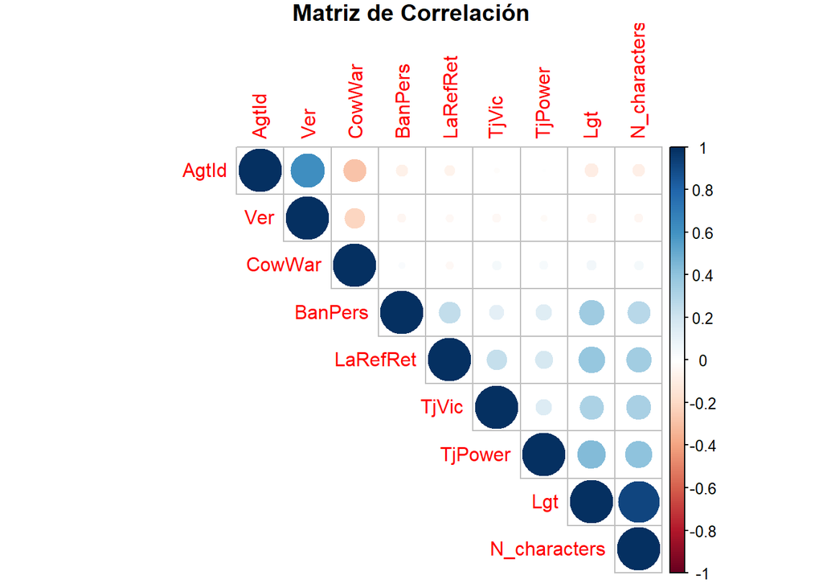

```
##                                          Con                        Contp
##  Bosnia and Herzegovina/Yugoslavia (former): 133   Government          :653
##  Colombia                                  : 128   Government/territory:843
##  Philippines/Mindanao                      : 126   Inter-group         :261
##  Syria                                     :  93   Other               :  2
##  Nepal                                     :  51   Territory           :109
##  South Sudan                               :  51
##  (Other)                                   :1286
##        PP                                   Reg          AgtId
##  Min.   :  1.00   Africa (excl MENA)          :584   Min.   :   1.0
##  1st Qu.: 55.00   Americas                    :195   1st Qu.: 568.8
##  Median : 90.00   Asia and Pacific            :377   Median :1135.5
##  Mean   : 84.87   Cross-regional              : 38   Mean   :1155.1
##  3rd Qu.:123.00   Europe and Eurasia          :411   3rd Qu.:1736.2
##  Max.   :160.00   Middle East and North Africa:263   Max.   :2317.0
##
##      Ver.x           Lgt.x         N_characters.x      CowWar.x
##  Min.   :1.000   Min.   :  1.000   Min.   :   329   Min.   :139.0
##  1st Qu.:1.000   1st Qu.:  1.000   1st Qu.:  2397   1st Qu.:817.0
##  Median :1.000   Median :  2.000   Median :  4354   Median :857.0
##  Mean   :1.249   Mean   :  6.275   Mean   : 11952   Mean   :759.3
##  3rd Qu.:1.000   3rd Qu.:  5.000   3rd Qu.:  9420   3rd Qu.:905.0
##  Max.   :4.000   Max.   :323.000   Max.   :908459   Max.   :941.0
##                                                     NA's   :753
##    BanPers.x         LaRefRet.x        TjPower.x          TjVic.x
##  Min.   :0.00000   Min.   :0.00000   Min.   :0.00000   Min.   :0.0000
##  1st Qu.:0.00000   1st Qu.:0.00000   1st Qu.:0.00000   1st Qu.:0.0000
##  Median :0.00000   Median :0.00000   Median :0.00000   Median :0.0000
##  Mean   :0.02088   Mean   :0.05942   Mean   :0.01017   Mean   :0.1997
##  3rd Qu.:0.00000   3rd Qu.:0.00000   3rd Qu.:0.00000   3rd Qu.:0.0000
##  Max.   :1.00000   Max.   :1.00000   Max.   :1.00000   Max.   :3.0000
##
```

#### 2.1. Outliers

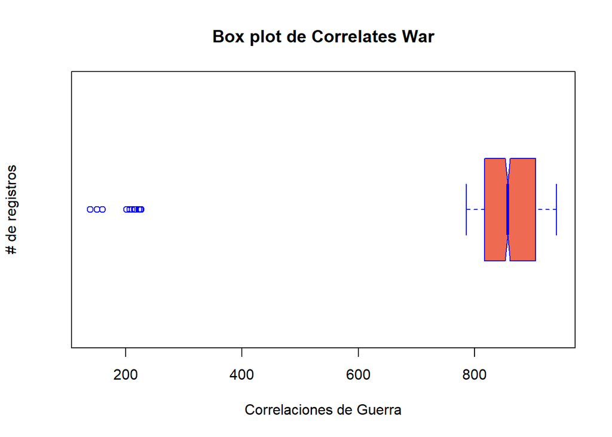

Se gestionan outliers con eliminación:

```r
values <- df3$CowWar.x
values <-boxplot.stats(values)$out
idx <- which(df3$CowWar.x %in% values)
#idx
C_outliers <- df3[idx,]
#head(C_outliers)

df4 <- c()

df4 <- data.frame(df3)
```

### 3. Crear el archivo limpio

Se anexa archivo limpio eliminando outliers y variable muy correlacionada (Lgt), Este archivo se usará para la visualización en Power BI o Tableau:

```r
#variable correlacionada a eliminar:
cols.SQLCuanti_Quit <- c("Lgt.x")
df4 <- df4[,!names(df4) %in% cols.SQLCuanti_Quit, drop = F]


archivo_clean <- df4[ which(df4$CowWar.x > 240),]
summary(archivo_clean)
```

```
##                           Con                       Contp           PP
##  Colombia                   :128   Government          :453   Min.   :  1.0
##  Philippines/Mindanao       :124   Government/territory:436   1st Qu.: 43.0
##  Nepal                      : 51   Inter-group         :  7   Median : 90.0
##  South Sudan/Sudan          : 43   Other               :  0   Mean   : 75.2
##  Croatia/Yugoslavia (former): 41   Territory           : 24   3rd Qu.: 99.0
##  Somalia                    : 37                              Max.   :158.0
##  (Other)                    :496
##                            Reg          AgtId            Ver.x
##  Africa (excl MENA)          :282   Min.   :   1.0   Min.   :1.000
##  Americas                    :169   1st Qu.: 399.2   1st Qu.:1.000
##  Asia and Pacific            :288   Median : 865.5   Median :1.000
##  Cross-regional              :  2   Mean   : 884.4   Mean   :1.055
##  Europe and Eurasia          :170   3rd Qu.:1303.2   3rd Qu.:1.000
##  Middle East and North Africa:  9   Max.   :2261.0   Max.   :3.000
##
##  N_characters.x      CowWar.x       BanPers.x         LaRefRet.x
##  Min.   :   442   Min.   :786.0   Min.   :0.00000   Min.   :0.00000
##  1st Qu.:  2504   1st Qu.:854.0   1st Qu.:0.00000   1st Qu.:0.00000
##  Median :  4561   Median :873.0   Median :0.00000   Median :0.00000
##  Mean   : 13166   Mean   :875.2   Mean   :0.02717   Mean   :0.06087
##  3rd Qu.:  9452   3rd Qu.:916.0   3rd Qu.:0.00000   3rd Qu.:0.00000
##  Max.   :908459   Max.   :941.0   Max.   :1.00000   Max.   :1.00000
##
##    TjPower.x          TjVic.x
##  Min.   :0.00000   Min.   :0.0000
##  1st Qu.:0.00000   1st Qu.:0.0000
##  Median :0.00000   Median :0.0000
##  Mean   :0.01304   Mean   :0.2207
##  3rd Qu.:0.00000   3rd Qu.:0.0000
##  Max.   :1.00000   Max.   :3.0000
##
```

```r
write.csv(archivo_clean,"pinzon_fichero_Visualizacion.csv",row.names=FALSE)
```

### 4. CONCLUSIONES DEL ANÁLISIS

En cuando a regiones, África ha sido el país con más acuerdos de paz.

Igualmente, el tema de restitución de tierras alarga mucho el texto del acuerdo de paz.

.